# Weather and Corn Yield Regressions

Orion Cardenas and Nathan Mueller

2/25/2022

## Weather Data Analysis

### Load the PRISM daily maximum temperatures

```r
# daily max temperature
# dimensions: counties x days x years
prism <- readMat("prismiowa.mat")

# look at county #1
t_1981_c1 <- prism$tmaxdaily.iowa[1,,1]
t_1981_c1[366]
```

```
## [1] NaN
```

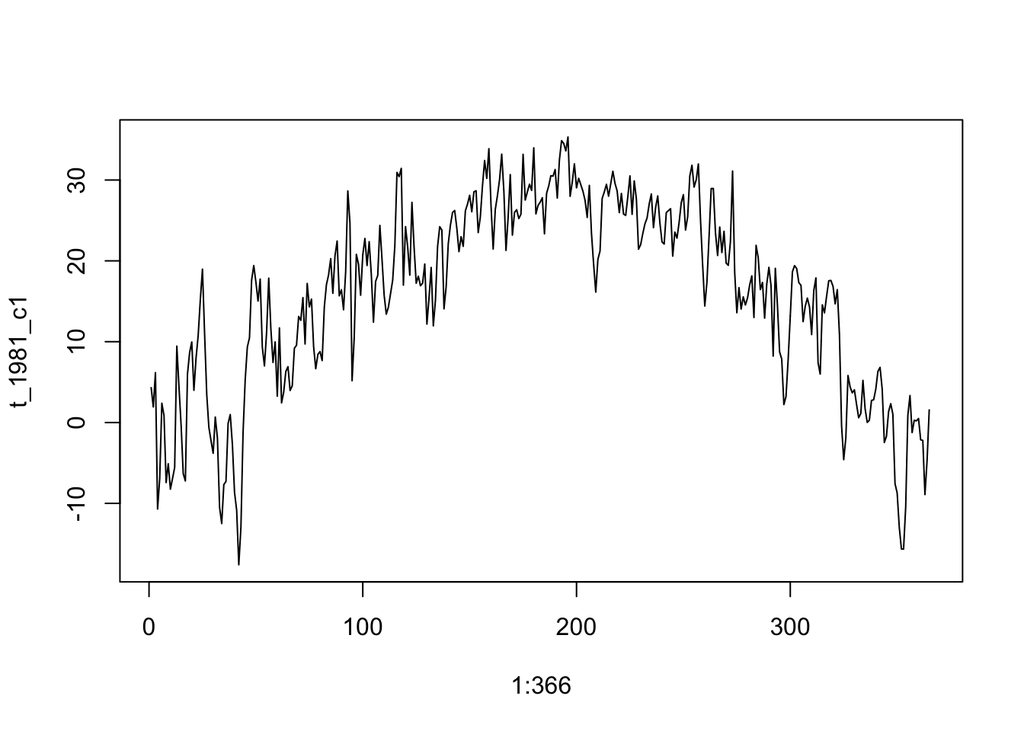

```r
plot(1:366, t_1981_c1, type = "l")
```

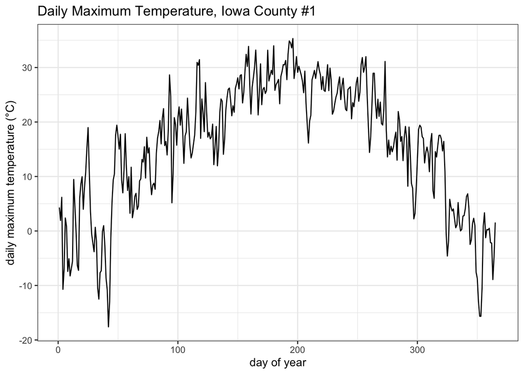

```r
ggplot() +
  geom_line(mapping = aes(x=1:366, y = t_1981_c1)) +
  theme_bw() +
  xlab("day of year") +
  ylab("daily maximum temperature (°C)") +
  ggtitle("Daily Maximum Temperature, Iowa County #1")
```

```r
# assign dimension names to tmax matrix
dimnames(prism$tmaxdaily.iowa) <- list(prism$COUNTYFP, 1:366, prism$years)

# converted 3d matrix into a data frame
tmaxdf <- as.data.frame.table(prism$tmaxdaily.iowa)

# relabel the columns
colnames(tmaxdf) <- c("countyfp","doy","year","tmax")
tmaxdf <- tibble(tmaxdf)
```

## Temperature trends

### Summer temperature trends: Winneshiek County

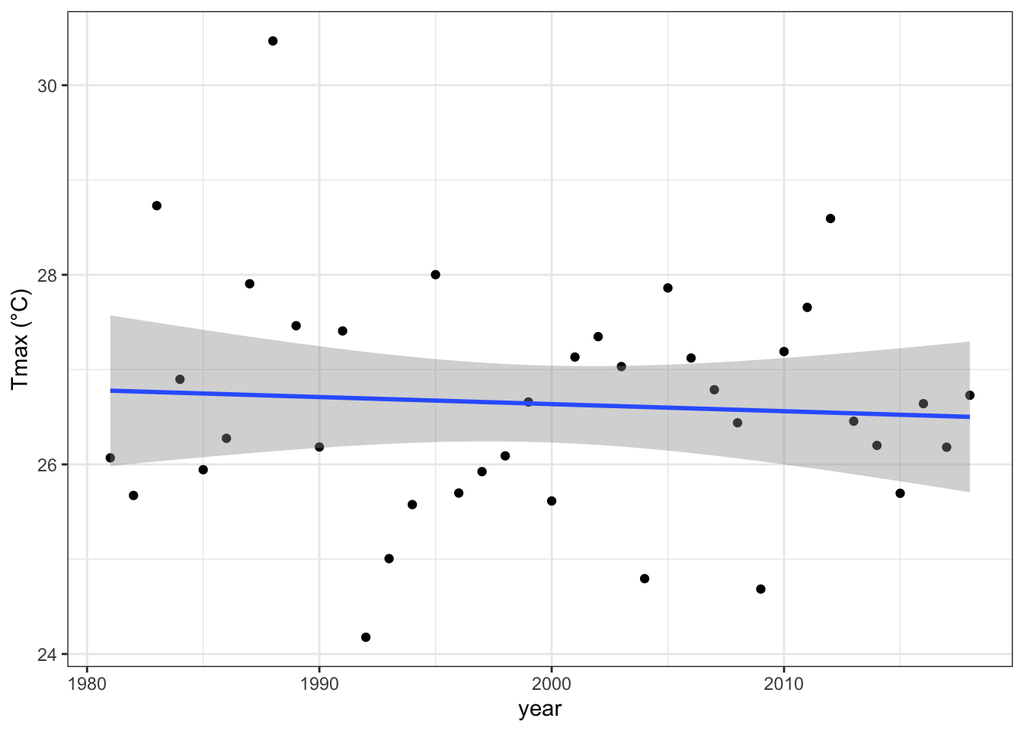

```r
tmaxdf$doy <- as.numeric(tmaxdf$doy)
tmaxdf$year <- as.numeric(as.character(tmaxdf$year))

winnesummer <- tmaxdf %>%
  filter(countyfp==191 & doy >= 152 & doy <= 243) %>%
  group_by(year) %>%
  summarize(meantmax = mean(tmax))

ggplot(winnesummer, mapping = aes(x = year, y = meantmax)) +
  geom_point() +
  theme_bw() +
  labs(x = "year", y = "Tmax (°C)") +
  geom_smooth(method = lm)
```

```r
lm_summertmax <- lm(meantmax ~ year, winnesummer)
summary(lm_summertmax)
```

```
##
## Call:
## lm(formula = meantmax ~ year, data = winnesummer)
##
## Residuals:
##     Min      1Q  Median      3Q     Max
## -2.5189 -0.7867 -0.0341  0.6859  3.7415
##
## Coefficients:
##             Estimate Std. Error t value Pr(>|t|)
## (Intercept) 41.57670   36.44848   1.141    0.262
## year        -0.00747    0.01823  -0.410    0.684
##
## Residual standard error: 1.232 on 36 degrees of freedom
## Multiple R-squared:  0.004644,   Adjusted R-squared:  -0.02301
## F-statistic: 0.168 on 1 and 36 DF,  p-value: 0.6844
```

### Winter Temperatures - Winneshiek County

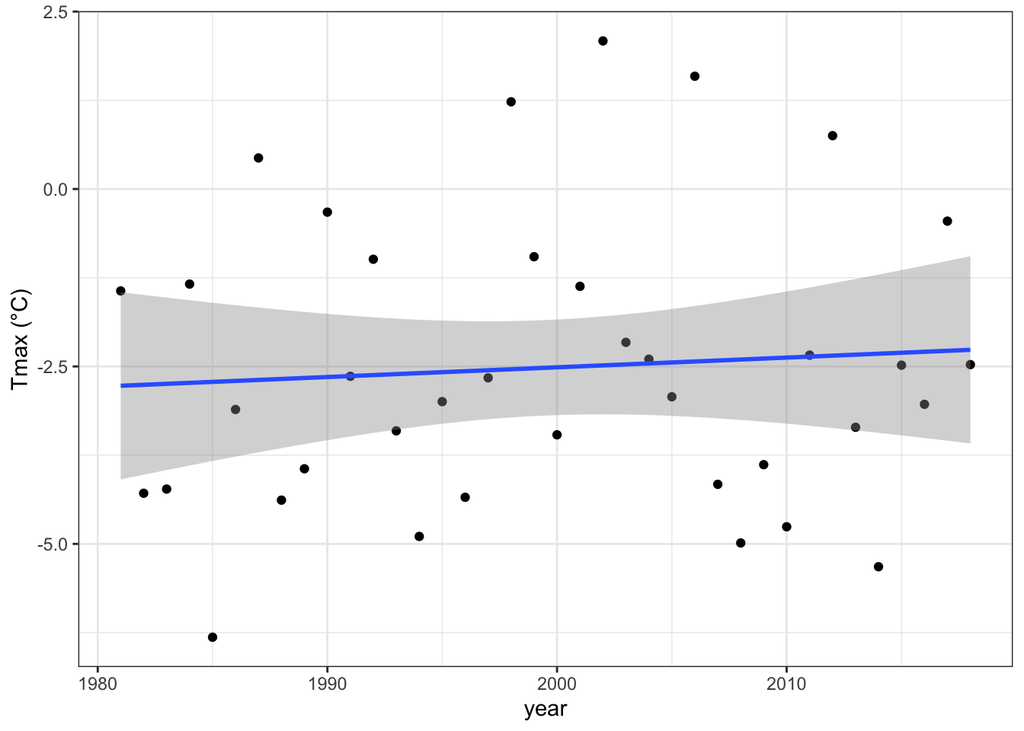

```r
winnewinter <- tmaxdf %>%
  filter(countyfp==191 & (doy <= 59 | doy >= 335) & !is.na(tmax)) %>%
  group_by(year) %>%
  summarize(meantmax = mean(tmax))

ggplot(winnewinter, mapping = aes(x = year, y = meantmax)) +
  geom_point() +
  theme_bw() +
  labs(x = "year", y = "Tmax (°C)") +
  geom_smooth(method = lm)
```

```r
lm_wintertmax <- lm(meantmax ~ year, winnewinter)
summary(lm_wintertmax)
```

```
##
## Call:
## lm(formula = meantmax ~ year, data = winnewinter)
##
## Residuals:
##     Min      1Q  Median      3Q     Max
## -3.5978 -1.4917 -0.3053  1.3778  4.5709
##
## Coefficients:
##              Estimate Std. Error t value Pr(>|t|)
## (Intercept) -29.87825   60.48100  -0.494    0.624
## year          0.01368    0.03025   0.452    0.654
##
## Residual standard error: 2.045 on 36 degrees of freedom
## Multiple R-squared:  0.005652,   Adjusted R-squared:  -0.02197
## F-statistic: 0.2046 on 1 and 36 DF,  p-value: 0.6537
```

### Multiple regression – Quadratic time trend

```r
winnewinter$yearsq <- winnewinter$year^2

lm_wintertmaxquad <- lm(meantmax ~ year + yearsq, winnewinter)
summary(lm_wintertmaxquad)
```

```
##
## Call:
## lm(formula = meantmax ~ year + yearsq, data = winnewinter)
##
## Residuals:
##     Min      1Q  Median      3Q     Max
## -3.3539 -1.2985 -0.2813  1.4055  4.2620
##
## Coefficients:
##               Estimate Std. Error t value Pr(>|t|)
## (Intercept) -1.086e+04  1.238e+04  -0.877    0.386
## year         1.085e+01  1.239e+01   0.876    0.387
## yearsq      -2.710e-03  3.097e-03  -0.875    0.388
##
## Residual standard error: 2.051 on 35 degrees of freedom
## Multiple R-squared:  0.02694,    Adjusted R-squared:  -0.02867
## F-statistic: 0.4845 on 2 and 35 DF,  p-value: 0.6201
```

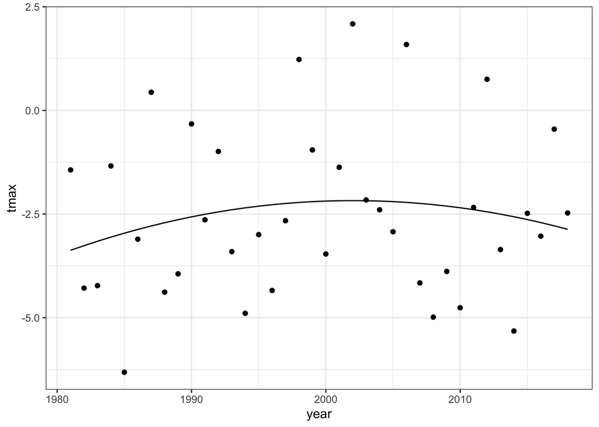

```r
winnewinter$fitted <- lm_wintertmaxquad$fitted.values

ggplot(winnewinter) +
  geom_point(mapping = aes(x = year, y = meantmax)) +
  geom_line(mapping = aes(x = year, y = fitted)) +
  theme_bw() +
  labs(x = "year", y = "tmax")
```

## Assignment

### Question 1a: Extract Winneshiek County corn yields, fit a linear time trend, make a plot. Is there a significant time trend?

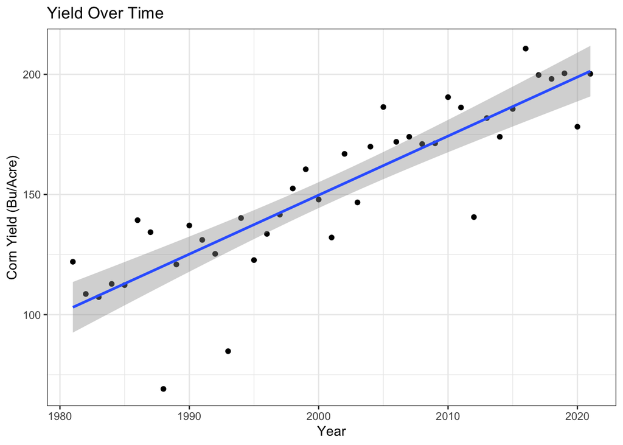

```r
winne_corn_yields = cornyields %>%
  filter(county_name == "WINNESHIEK") %>%
  group_by(year)

ggplot(winne_corn_yields, mapping = aes(x = year, y = yield)) +
  geom_point() +
  theme_bw() +
  labs(x = "Year", y = "Corn Yield (Bu/Acre)") +
  ggtitle("Yield Over Time") +
  geom_smooth(method = lm)
```

```r
lm_winne_corn_yields = lm(yield ~ year, winne_corn_yields)

summary(lm_winne_corn_yields)
```

```
##
## Call:
## lm(formula = yield ~ year, data = winne_corn_yields)
##
## Residuals:
##     Min      1Q  Median      3Q     Max
## -51.163  -1.841   2.363   9.437  24.376
##
## Coefficients:
##              Estimate Std. Error t value Pr(>|t|)
## (Intercept) -4763.290    448.286  -10.63 4.46e-13 ***
## year            2.457      0.224   10.96 1.77e-13 ***
## ---
## Signif. codes:  0 '***' 0.001 '**' 0.01 '*' 0.05 '.' 0.1 ' ' 1
##
## Residual standard error: 16.97 on 39 degrees of freedom
## Multiple R-squared:  0.7551, Adjusted R-squared:  0.7488
## F-statistic: 120.2 on 1 and 39 DF,  p-value: 1.767e-13
```

### Question 1b: Fit a quadratic time trend (i.e., year + year^2) and make a plot. Is there evidence for slowing yield growth?

No, there is no evidence for slowing yield growth. After fitting a quadratic time trend, there appears to be a positive quadratic trend indicating increasing growth over time.

```r
winne_corn_yields$yearsq = winne_corn_yields$year^2

lm_wcy_quad = lm(yield ~ year + yearsq, winne_corn_yields)
summary(lm_wcy_quad)
```

```
##
## Call:
## lm(formula = yield ~ year + yearsq, data = winne_corn_yields)
##
## Residuals:
##     Min      1Q  Median      3Q     Max
## -51.384  -3.115   1.388   9.743  25.324
##
## Coefficients:
##               Estimate Std. Error t value Pr(>|t|)
## (Intercept)  2.583e+04  8.580e+04   0.301    0.765
## year        -2.812e+01  8.576e+01  -0.328    0.745
## yearsq       7.641e-03  2.143e-02   0.357    0.723
##
## Residual standard error: 17.17 on 38 degrees of freedom
## Multiple R-squared:  0.7559, Adjusted R-squared:  0.7431
## F-statistic: 58.84 on 2 and 38 DF,  p-value: 2.311e-12
```

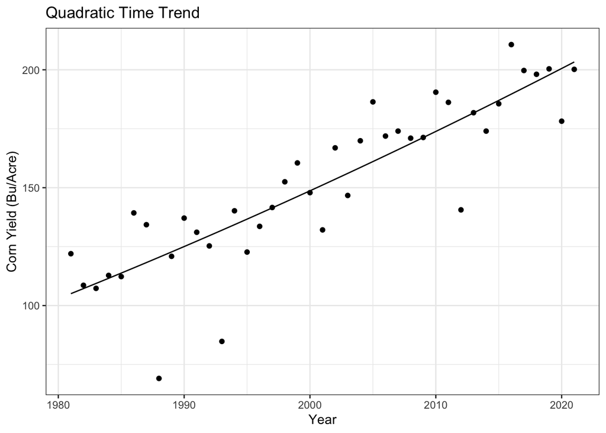

```r
winne_corn_yields$fitted = lm_wcy_quad$fitted.values

ggplot(winne_corn_yields) +
  geom_point(mapping = aes(x = year, y = yield)) +
  geom_line(mapping = aes(x = year, y = fitted)) +
  theme_bw() +
  ggtitle("Quadratic Time Trend") +
  labs(x = "Year", y = "Corn Yield (Bu/Acre)")
```

### Question 2 – Time Series: Let’s analyze the relationship between temperature and yields for the Winneshiek County time series. Use data on yield and summer avg Tmax. Is adding year or Tmax^2 to your model helpful? Make a plot and interpret the results.

Summer avg Tmax alone does not appear to be a good predictor of corn yield (p = 0.29). Adding both year and summer avg Tmax does improve the model. The model with year and avg T max had the most significant p value although the meantmax variable was not significant. The quadratic model was significant (p=0.007) and all of the variables in the model were good predictors of meantmax.

```r
winne_yield_summertmax = inner_join(winne_corn_yields, winnesummer)
winne_yield_summertmax$meantmaxq = winne_yield_summertmax$meantmax^2

lm_winne_yieldtmax = lm(yield ~ meantmax, winne_yield_summertmax)

lm_winne_yieldtmaxyear = lm(yield ~ meantmax + year, winne_yield_summertmax)

lm_winne_yieldtmaxq = lm(yield ~ meantmax + meantmaxq, winne_yield_summertmax)

summary(lm_winne_yieldtmax)
```

```
##
## Call:
## lm(formula = yield ~ meantmax, data = winne_yield_summertmax)
##
## Residuals:
##    Min     1Q Median     3Q    Max
## -71.96 -19.85  -3.19  24.64  61.72
##
## Coefficients:
##             Estimate Std. Error t value Pr(>|t|)
## (Intercept)  275.876    118.335   2.331   0.0255 *
## meantmax      -4.763      4.438  -1.073   0.2902
## ---
## Signif. codes:  0 '***' 0.001 '**' 0.01 '*' 0.05 '.' 0.1 ' ' 1
##
## Residual standard error: 32.88 on 36 degrees of freedom
## Multiple R-squared:  0.03101,    Adjusted R-squared:  0.004098
## F-statistic: 1.152 on 1 and 36 DF,  p-value: 0.2902
```

```r
summary(lm_winne_yieldtmaxyear)
```

```
##
## Call:
## lm(formula = yield ~ meantmax + year, data = winne_yield_summertmax)
##
## Residuals:
##     Min      1Q  Median      3Q     Max
## -53.071  -7.269   2.271   9.935  27.505
##
## Coefficients:
##              Estimate Std. Error t value Pr(>|t|)
## (Intercept) -4791.774    513.812  -9.326 5.10e-11 ***
## meantmax       -3.201      2.308  -1.387    0.174
## year            2.514      0.253   9.934 1.01e-11 ***
## ---
## Signif. codes:  0 '***' 0.001 '**' 0.01 '*' 0.05 '.' 0.1 ' ' 1
##
## Residual standard error: 17.06 on 35 degrees of freedom
## Multiple R-squared:  0.7463, Adjusted R-squared:  0.7318
## F-statistic: 51.48 on 2 and 35 DF,  p-value: 3.761e-11
```

```r
summary(lm_winne_yieldtmaxq)
```

```
##
## Call:
## lm(formula = yield ~ meantmax + meantmaxq, data = winne_yield_summertmax)
##
## Residuals:
##     Min      1Q  Median      3Q     Max
## -56.587 -22.262  -0.982  22.409  52.798
##
## Coefficients:
##              Estimate Std. Error t value Pr(>|t|)
## (Intercept) -4223.604   1446.639  -2.920  0.00609 **
## meantmax      328.918    107.068   3.072  0.00410 **
## meantmaxq      -6.173      1.979  -3.119  0.00362 **
## ---
## Signif. codes:  0 '***' 0.001 '**' 0.01 '*' 0.05 '.' 0.1 ' ' 1
##
## Residual standard error: 29.5 on 35 degrees of freedom
## Multiple R-squared:  0.2417, Adjusted R-squared:  0.1984
## F-statistic: 5.579 on 2 and 35 DF,  p-value: 0.007887
```

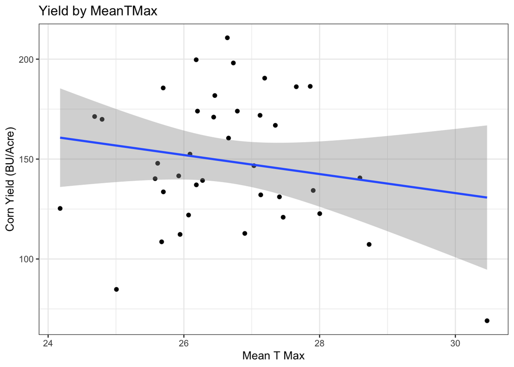

```r
ggplot(winne_yield_summertmax, mapping = aes(x = meantmax, y = yield)) +
  geom_point() +
  theme_bw() +
  labs(x = "Mean T Max", y = "Corn Yield (BU/Acre)") +
  ggtitle("Yield by MeanTMax") +
  geom_smooth(method = lm)
```

### Question 3 – Cross-Section: Analyze the relationship between temperature and yield across all counties in 2018. Is there a relationship? Interpret the results.

Meantmax summer is a fair predictor of corn yield across all counties (p=0.06). The model improves when adding the quadratic variable (p=0.001). Meantmax winter was not a good model (p= 0.9). The performance of the meantmax winter model was drastically improved when the quadratic variable was added (p=0.0005). The combination of meantmax summer and meantmax winter produced a good model where both variables were good predictors (p=0.0004). It was also greatly improved with the addition of the quadratic variables.

```r
allcounty_corn_yields_2018 = cornyields[cornyields$year == 2018,]
allcounty_corn_yields_2018$countyfp = as.factor(allcounty_corn_yields_2018$county_ansi)

allcounty_summer_2018 = tmaxdf %>%
  filter(year == 2018 & doy >= 152 & doy <= 243) %>%
  group_by(year, countyfp) %>%
  summarize(meantmaxsum = mean(tmax))
allcounty_winter_2018 = tmaxdf %>%
  filter((doy <= 59) & !is.na(tmax)) %>%
  filter(year == 2018) %>%
  group_by(year, countyfp) %>%
  summarize(meantmaxwin = mean(tmax))
allcounty_corn_yields_2018 = left_join(allcounty_corn_yields_2018, allcounty_summer_2018, keep=F, by = "countyfp")

allcounty_corn_yields_2018 = left_join(allcounty_corn_yields_2018, allcounty_winter_2018, keep=F, by = "countyfp")

allcounty_corn_yields_2018$meantmaxsumq = allcounty_corn_yields_2018$meantmaxsum^2

allcounty_corn_yields_2018$meantmaxwinq = allcounty_corn_yields_2018$meantmaxwin^2

lm_allcy_tempyield_sum = lm(yield ~ meantmaxsum, allcounty_corn_yields_2018)

lm_allcy_tempyield_sumq = lm(yield ~ meantmaxsum + meantmaxsumq, allcounty_corn_yields_2018)


lm_allcy_tempyield_win = lm(yield ~ meantmaxwin, allcounty_corn_yields_2018)

lm_allcy_tempyield_winq = lm(yield ~ meantmaxwin + meantmaxwinq, allcounty_corn_yields_2018)

lm_allcy_tempyield_sumwin1 = lm(yield ~ meantmaxsum + meantmaxwin, allcounty_corn_yields_2018)

lm_allcy_tempyield_sumwin2 = lm(yield ~ meantmaxsum + meantmaxwin + meantmaxsumq + meantmaxwinq, allcounty_corn_yields_2018)

summary(lm_allcy_tempyield_sum)
```

```
##
## Call:
## lm(formula = yield ~ meantmaxsum, data = allcounty_corn_yields_2018)
##
## Residuals:
##     Min      1Q  Median      3Q     Max
## -42.983 -15.041   0.955  16.795  31.999
##
## Coefficients:
##             Estimate Std. Error t value Pr(>|t|)
## (Intercept)  312.466     63.387   4.929 3.69e-06 ***
## meantmaxsum   -4.216      2.241  -1.882   0.0631 .
## ---
## Signif. codes:  0 '***' 0.001 '**' 0.01 '*' 0.05 '.' 0.1 ' ' 1
##
## Residual standard error: 19.64 on 91 degrees of freedom
## Multiple R-squared:  0.03745,    Adjusted R-squared:  0.02687
## F-statistic: 3.541 on 1 and 91 DF,  p-value: 0.06308
```

```r
summary(lm_allcy_tempyield_sumq)
```

```
##
## Call:
## lm(formula = yield ~ meantmaxsum + meantmaxsumq, data = allcounty_corn_yields_2018)
##
## Residuals:
##     Min      1Q  Median      3Q     Max
## -44.221 -15.399   5.007  14.541  30.879
##
## Coefficients:
##               Estimate Std. Error t value Pr(>|t|)
## (Intercept)  -5501.602   1860.830  -2.957  0.00397 **
## meantmaxsum    406.789    131.493   3.094  0.00263 **
## meantmaxsumq    -7.256      2.321  -3.126  0.00239 **
## ---
## Signif. codes:  0 '***' 0.001 '**' 0.01 '*' 0.05 '.' 0.1 ' ' 1
##
## Residual standard error: 18.75 on 90 degrees of freedom
## Multiple R-squared:  0.1317, Adjusted R-squared:  0.1124
## F-statistic: 6.827 on 2 and 90 DF,  p-value: 0.001736
```

```r
summary(lm_allcy_tempyield_win)
```

```
##
## Call:
## lm(formula = yield ~ meantmaxwin, data = allcounty_corn_yields_2018)
##
## Residuals:
##     Min      1Q  Median      3Q     Max
## -43.600 -13.403  -0.109  17.861  32.699
##
## Coefficients:
##             Estimate Std. Error t value Pr(>|t|)
## (Intercept) 192.8934     3.5487  54.356   <2e-16 ***
## meantmaxwin  -0.1475     1.1746  -0.126      0.9
## ---
## Signif. codes:  0 '***' 0.001 '**' 0.01 '*' 0.05 '.' 0.1 ' ' 1
##
## Residual standard error: 20.01 on 91 degrees of freedom
## Multiple R-squared:  0.0001732,  Adjusted R-squared:  -0.01081
## F-statistic: 0.01577 on 1 and 91 DF,  p-value: 0.9004
```

```r
summary(lm_allcy_tempyield_winq)
```

```
##
## Call:
## lm(formula = yield ~ meantmaxwin + meantmaxwinq, data = allcounty_corn_yields_2018)
##
## Residuals:
##     Min      1Q  Median      3Q     Max
## -49.631 -11.680   2.981  14.631  33.940
##
## Coefficients:
##              Estimate Std. Error t value Pr(>|t|)
## (Intercept)  187.0200     3.5855  52.161  < 2e-16 ***
## meantmaxwin  -12.3404     3.1936  -3.864 0.000210 ***
## meantmaxwinq  -2.6303     0.6479  -4.060 0.000105 ***
## ---
## Signif. codes:  0 '***' 0.001 '**' 0.01 '*' 0.05 '.' 0.1 ' ' 1
##
## Residual standard error: 18.5 on 90 degrees of freedom
## Multiple R-squared:  0.1549, Adjusted R-squared:  0.1361
## F-statistic:  8.25 on 2 and 90 DF,  p-value: 0.0005131
```

```r
summary(lm_allcy_tempyield_sumwin1)
```

```
##
## Call:
## lm(formula = yield ~ meantmaxsum + meantmaxwin, data = allcounty_corn_yields_2018)
##
## Residuals:
##     Min      1Q  Median      3Q     Max
## -40.172 -11.908  -0.057  14.654  32.094
##
## Coefficients:
##             Estimate Std. Error t value Pr(>|t|)
## (Intercept)  748.803    135.388   5.531 3.09e-07 ***
## meantmaxsum  -18.912      4.605  -4.107 8.80e-05 ***
## meantmaxwin    8.501      2.368   3.590 0.000539 ***
## ---
## Signif. codes:  0 '***' 0.001 '**' 0.01 '*' 0.05 '.' 0.1 ' ' 1
##
## Residual standard error: 18.47 on 90 degrees of freedom
## Multiple R-squared:  0.158,  Adjusted R-squared:  0.1393
## F-statistic: 8.444 on 2 and 90 DF,  p-value: 0.0004356
```

```r
summary(lm_allcy_tempyield_sumwin2)
```

```
##
## Call:
## lm(formula = yield ~ meantmaxsum + meantmaxwin + meantmaxsumq +
##     meantmaxwinq, data = allcounty_corn_yields_2018)
##
## Residuals:
##     Min      1Q  Median      3Q     Max
## -44.886  -9.707   0.920  11.477  26.037
##
## Coefficients:
##                Estimate Std. Error t value Pr(>|t|)
## (Intercept)  -6783.3522  2454.3346  -2.764  0.00696 **
## meantmaxsum    518.2609   176.0455   2.944  0.00414 **
## meantmaxwin      9.8176     5.6831   1.727  0.08759 .
## meantmaxsumq    -9.5599     3.1494  -3.035  0.00316 **
## meantmaxwinq    -0.2643     0.8728  -0.303  0.76276
## ---
## Signif. codes:  0 '***' 0.001 '**' 0.01 '*' 0.05 '.' 0.1 ' ' 1
##
## Residual standard error: 16.62 on 88 degrees of freedom
## Multiple R-squared:  0.3331, Adjusted R-squared:  0.3028
## F-statistic: 10.99 on 4 and 88 DF,  p-value: 2.832e-07
```

```r
AIC(lm_allcy_tempyield_sum, lm_allcy_tempyield_sumq, lm_allcy_tempyield_win, lm_allcy_tempyield_winq, lm_allcy_tempyield_sumwin1, lm_allcy_tempyield_sumwin2)
```

```
##                            df      AIC
## lm_allcy_tempyield_sum      3 821.6913
## lm_allcy_tempyield_sumq     4 814.1046
## lm_allcy_tempyield_win      3 825.2250
## lm_allcy_tempyield_winq     4 811.5862
## lm_allcy_tempyield_sumwin1  4 811.2477
## lm_allcy_tempyield_sumwin2  6 793.5592
```

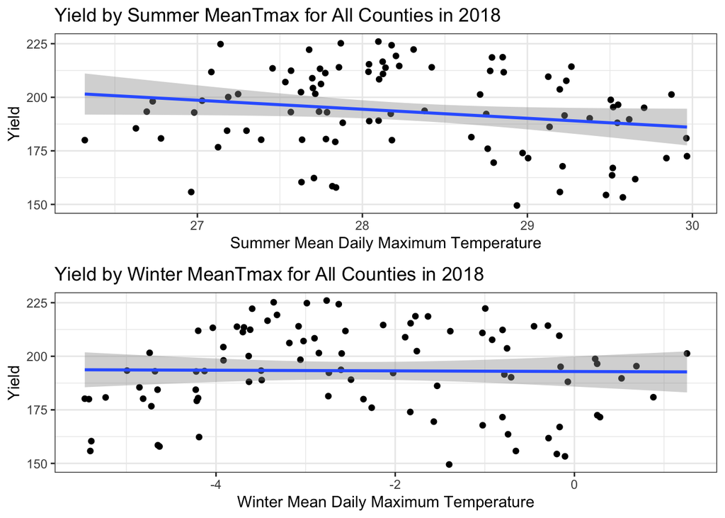

```r
sumyieldplot2018 = ggplot(allcounty_corn_yields_2018, mapping = aes(x = meantmaxsum, y = yield)) +
  geom_point() +
  theme_bw() +
  labs(x = "Summer Mean Daily Maximum Temperature", y = "Yield") +
  ggtitle("Yield by Summer MeanTmax for All Counties in 2018") +
  geom_smooth(method = lm)

winyieldplot2018 = ggplot(allcounty_corn_yields_2018, mapping = aes(x = meantmaxwin, y = yield)) +
  geom_point() +
  theme_bw() +
  labs(x = "Winter Mean Daily Maximum Temperature", y = "Yield") +
  ggtitle("Yield by Winter MeanTmax for All Counties in 2018") +
  geom_smooth(method = lm)

grid.arrange(sumyieldplot2018,winyieldplot2018)
```

### Question 4 – Panel: One way to leverage multiple time series is to group all data into what is called a “panel” regression. Convert the county ID code (“countyfp” or “county_ansi”) into factor using as.factor, then include this variable in a regression using all counties’ yield and summer temperature data. How does the significance of your temperature coefficients (Tmax, Tmax^2) change? Make a plot comparing actual and fitted yields and interpret the results of your model.

Including the county variable in our regression results in a strong model. The two temperature variables (Tmax and Tmax^2) are highly significant in this model (p<2.2e-16). They are better predictors of corn yield than the county variables.

```r
cornyields$countyfp = as.factor(cornyields$county_ansi)

allcounty_summer_ay = tmaxdf %>%
  filter(doy >= 152 & doy <= 243) %>%
  group_by(year, countyfp) %>%
  summarize(meantmax = mean(tmax))
allcounty_cy_summertemp = inner_join(cornyields, allcounty_summer_ay, by=c("countyfp", "year")) %>%
  na.omit(.)

allcounty_cy_summertemp$meantmaxq = allcounty_cy_summertemp$meantmax^2

lm_allcy_summertempyield = lm(yield ~ countyfp + meantmax + meantmaxq, allcounty_cy_summertemp)
summary(lm_allcy_summertempyield)
```

```
##
## Call:
## lm(formula = yield ~ countyfp + meantmax + meantmaxq, data = allcounty_cy_summertemp)
##
## Residuals:
##     Min      1Q  Median      3Q     Max
## -95.088 -21.438  -3.026  23.570  77.941
##
## Coefficients:
##               Estimate Std. Error t value Pr(>|t|)
## (Intercept) -2102.2327   139.2946 -15.092  < 2e-16 ***
## countyfp3      -4.5577     7.0388  -0.648 0.517347
## countyfp5       1.9797     7.0743   0.280 0.779612
## countyfp7     -19.1369     7.0864  -2.701 0.006955 **
## countyfp9       4.3024     7.0416   0.611 0.541240
## countyfp11      6.2752     7.0459   0.891 0.373195
## countyfp13      6.2028     7.0520   0.880 0.379147
## countyfp15     14.3129     7.0414   2.033 0.042157 *
## countyfp17     10.2595     7.0568   1.454 0.146076
## countyfp19      6.6549     7.0596   0.943 0.345912
## countyfp21      7.5427     7.0503   1.070 0.284760
## countyfp23      8.0045     7.0493   1.135 0.256242
## countyfp25      9.3627     7.0468   1.329 0.184048
## countyfp27      8.8039     7.0426   1.250 0.211348
## countyfp29      6.0858     7.0389   0.865 0.387315
## countyfp31     14.9921     7.0443   2.128 0.033381 *
## countyfp33      3.7400     7.0668   0.529 0.596677
## countyfp35     12.8689     7.0455   1.827 0.067848 .
## countyfp37      1.3837     7.0714   0.196 0.844876
## countyfp39    -24.9874     7.0863  -3.526 0.000427 ***
## countyfp41      5.5213     7.0521   0.783 0.433716
## countyfp43      7.9986     7.0648   1.132 0.257632
## countyfp45      9.7142     7.0455   1.379 0.168043
## countyfp47      5.5829     7.0436   0.793 0.428054
## countyfp49     10.5962     7.0391   1.505 0.132323
## countyfp51    -14.6474     7.0887  -2.066 0.038872 *
## countyfp53    -16.7641     7.0865  -2.366 0.018051 *
## countyfp55      8.6421     7.0667   1.223 0.221435
## countyfp57     10.8382     7.0391   1.540 0.123719
## countyfp59      2.0837     7.0635   0.295 0.768011
```

[output cut: 62 more lines]

```
## countyfp185   -22.9077     7.0863  -3.233 0.001237 **
## countyfp187    13.1211     7.0472   1.862 0.062700 .
## countyfp189     7.5593     7.0757   1.068 0.285441
## countyfp191     4.0826     7.0867   0.576 0.564584
## countyfp193     2.3508     7.0395   0.334 0.738436
## countyfp195     5.9103     7.0954   0.833 0.404908
## countyfp197    10.4404     7.0518   1.481 0.138817
## meantmax      167.9699     9.8950  16.975  < 2e-16 ***
## meantmaxq      -3.1324     0.1758 -17.820  < 2e-16 ***
## ---
## Signif. codes:  0 '***' 0.001 '**' 0.01 '*' 0.05 '.' 0.1 ' ' 1
##
## Residual standard error: 30.68 on 3647 degrees of freedom
## Multiple R-squared:  0.2585, Adjusted R-squared:  0.2382
## F-statistic: 12.71 on 100 and 3647 DF,  p-value: < 2.2e-16
```

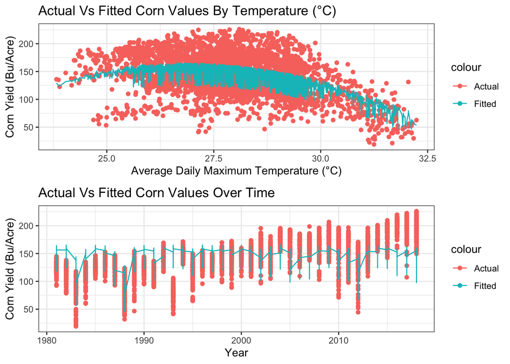

```r
allcounty_cy_summertemp$fitted = lm_allcy_summertempyield$fitted.values

actualvfittedplot1 = ggplot(allcounty_cy_summertemp) +
      geom_point(mapping = aes(x = meantmax, y = yield, col="Actual")) +
      geom_line(mapping = aes(x = meantmax, y = fitted, col="Fitted")) +
      theme_bw() +
      labs(x = "Average Daily Maximum Temperature (°C)", y = "Corn Yield (Bu/Acre)") +
      ggtitle("Actual Vs Fitted Corn Values By Temperature (°C)")

actualvfittedplot2 = ggplot(allcounty_cy_summertemp) +
      geom_point(mapping = aes(x = year, y = yield, col="Actual")) +
      geom_line(mapping = aes(x = year, y = fitted, col="Fitted")) +
      theme_bw() +
      labs(x = "Year", y = "Corn Yield (Bu/Acre)") +
      ggtitle("Actual Vs Fitted Corn Values Over Time")
grid.arrange(actualvfittedplot1, actualvfittedplot2)
```

### Question 5 – Soybeans: Download NASS data on soybean yields and explore either a time series relationship for a given county, the cross-sectional relationship for a given year, or a panel across all counties and years.

I decided to do a panel for soybean yield across all Iowa counties and years. The model is strong overall (p < 2e-16) and the temperature variables are highly significant in this model (p < 2e-16).

```r
# panel study
soybeanyields$countyfp = as.factor(soybeanyields$county_ansi)

allcounty_summer_ay = tmaxdf %>%
  filter(doy >= 152 & doy <= 243) %>%
  group_by(year, countyfp) %>%
  summarize(meantmax = mean(tmax))
allcounty_sy_summertemp = inner_join(soybeanyields, allcounty_summer_ay, by=c("countyfp", "year")) %>%
  na.omit(.)

allcounty_sy_summertemp$meantmaxq = allcounty_sy_summertemp$meantmax^2

lm_allsy_summertempyield = lm(yield ~ countyfp + meantmax + meantmaxq, allcounty_sy_summertemp)
summary(lm_allsy_summertempyield)
```

```
##
## Call:
## lm(formula = yield ~ countyfp + meantmax + meantmaxq, data = allcounty_sy_summertemp)
##
## Residuals:
##      Min       1Q   Median       3Q      Max
## -26.3420  -5.0781   0.1391   5.6957  23.3156
##
## Coefficients:
##               Estimate Std. Error t value Pr(>|t|)
## (Intercept) -473.22020   35.31694 -13.399  < 2e-16 ***
## countyfp3     -1.33067    1.78479  -0.746 0.455979
## countyfp5      1.18581    1.79377   0.661 0.508610
## countyfp7     -5.05205    1.78485  -2.831 0.004673 **
## countyfp9      2.27560    1.78549   1.274 0.202570
## countyfp11     3.76697    1.78659   2.108 0.035058 *
## countyfp13     3.06023    1.78812   1.711 0.087087 .
## countyfp15     2.26044    1.78543   1.266 0.205578
## countyfp17     2.86725    1.78934   1.602 0.109151
## countyfp19     2.10098    1.79005   1.174 0.240591
## countyfp21     2.17637    1.78768   1.217 0.223520
## countyfp23     1.60285    1.78744   0.897 0.369921
## countyfp25     1.18399    1.78680   0.663 0.507609
## countyfp27     2.68711    1.78575   1.505 0.132474
## countyfp29     1.16997    1.78479   0.656 0.512173
## countyfp31     6.15534    1.78616   3.446 0.000575 ***
## countyfp33    -0.18436    1.79188  -0.103 0.918059
## countyfp35     6.11706    1.78646   3.424 0.000624 ***
## countyfp37    -0.36964    1.79304  -0.206 0.836684
## countyfp39    -6.42241    1.79681  -3.574 0.000356 ***
## countyfp41     1.32547    1.78813   0.741 0.458584
## countyfp43     4.25193    1.79135   2.374 0.017667 *
## countyfp45     5.13733    1.78646   2.876 0.004055 **
## countyfp47     2.93288    1.78600   1.642 0.100646
## countyfp49     2.36345    1.78485   1.324 0.185528
## countyfp51    -3.73355    1.78553  -2.091 0.036596 *
## countyfp53    -5.09414    1.79686  -2.835 0.004608 **
## countyfp55     4.58864    1.79184   2.561 0.010482 *
## countyfp57     3.84562    1.78486   2.155 0.031260 *
## countyfp59    -0.26459    1.79103  -0.148 0.882565
```

[output cut: 62 more lines]

```
## countyfp185   -6.15060    1.79683  -3.423 0.000626 ***
## countyfp187    1.69354    1.78691   0.948 0.343322
## countyfp189   -0.52784    1.79414  -0.294 0.768618
## countyfp191    0.56630    1.79690   0.315 0.752664
## countyfp193    0.15300    1.78496   0.086 0.931696
## countyfp195    0.03866    1.79911   0.021 0.982859
## countyfp197    0.97677    1.78806   0.546 0.584913
## meantmax      37.95824    2.50875  15.130  < 2e-16 ***
## meantmaxq     -0.69553    0.04457 -15.607  < 2e-16 ***
## ---
## Signif. codes:  0 '***' 0.001 '**' 0.01 '*' 0.05 '.' 0.1 ' ' 1
##
## Residual standard error: 7.78 on 3653 degrees of freedom
## Multiple R-squared:  0.215,  Adjusted R-squared:  0.1935
## F-statistic:    10 on 100 and 3653 DF,  p-value: < 2.2e-16
```

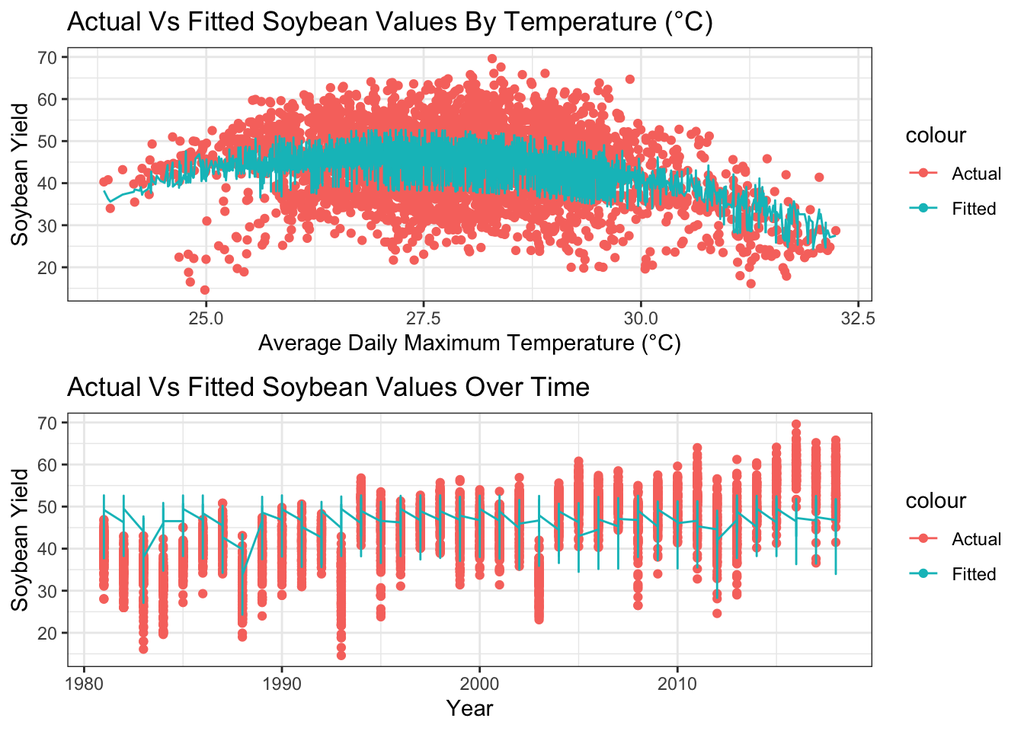

```r
allcounty_sy_summertemp$fitted = lm_allsy_summertempyield$fitted.values

actualvfittedplot3 = ggplot(allcounty_sy_summertemp) +
      geom_point(mapping = aes(x = meantmax, y = yield, col="Actual")) +
      geom_line(mapping = aes(x = meantmax, y = fitted, col="Fitted")) +
      theme_bw() +
      labs(x = "Average Daily Maximum Temperature (°C)", y = "Soybean Yield") +
      ggtitle("Actual Vs Fitted Soybean Values By Temperature (°C)")

actualvfittedplot4 = ggplot(allcounty_sy_summertemp) +
      geom_point(mapping = aes(x = year, y = yield, col="Actual")) +
      geom_line(mapping = aes(x = year, y = fitted, col="Fitted")) +
      theme_bw() +
      labs(x = "Year", y = "Soybean Yield") +
      ggtitle("Actual Vs Fitted Soybean Values Over Time")
grid.arrange(actualvfittedplot3, actualvfittedplot4)
```